# Data, NAs and Q2

YZ

4/4/2021

# III.Data Transformation

## 3.1 Data Acquisitiion

- Download the weather website by httr and GET function;
- Extract the table data from the website by html_table function from rvest package.

```r
library(httr)
library(rvest)
from.url<-'https://i-weather.com/weather/washington/history/monthly-history/?gid=4140963&station=19064&month=TODOMONTH&year=TODOYEAR&language=english&country=us-united-states'
todo<-expand.grid(2019:2020,1:12)
names(todo)<-c('year','month')
todo<-todo[order(todo$year,todo$month),]


apply(todo,1,function(xxx)
{
cat(paste(xxx,collapse=","),"====\n")
   gsub('TODOYEAR',xxx[1],from.url)->inter.url
   gsub('TODOMONTH',xxx[2],inter.url)->inter.url

   while(1)
   {
   GET(inter.url)->inter.web
   if(length(grep('</html>',content(inter.web,'text')))) break;
   }

   read_html(inter.web)->inter.webcontent
   html_table(inter.webcontent)->inter.tables
   sapply(inter.tables,function(ttt) "Daily minimum temperature" %in% names(ttt))->table.wanted

   inter.tables[[which(table.wanted)]]->table.wanted

   return(table.wanted)
})->resu
```

```
## 2019,1 ====
## 2019,2 ====
## 2019,3 ====
## 2019,4 ====
## 2019,5 ====
## 2019,6 ====
## 2019,7 ====
## 2019,8 ====
## 2019,9 ====
## 2019,10 ====
## 2019,11 ====
## 2019,12 ====
## 2020,1 ====
## 2020,2 ====
## 2020,3 ====
## 2020,4 ====
## 2020,5 ====
## 2020,6 ====
## 2020,7 ====
## 2020,8 ====
## 2020,9 ====
## 2020,10 ====
## 2020,11 ====
## 2020,12 ====
```

```r
unique(lapply(resu,names))
```

```
## [[1]]
##  [1] "Date"                      "Daily minimum temperature"
##  [3] "Daily maximum temperature" "Maximum steady wind"
##  [5] "Maximum wind gust"         "Total daily precipitation"
##  [7] "Snow depth"                "Pressure"
##  [9] "Icon"                      "Description"
```

```r
do.call('rbind',resu)->dat

#library(xls)
#write.xlsx(dat,file='data.xlsx',row.names=F)

save(dat,file='dat.RData')
```

We download a complete weather dataset with 10 variables of 24 months from year 2019 to 2020, rbind and save them as a data.frame; the data can be exported as an xlsx file or saved as RData format.

## 3.2 Data Manipulation

- Select 6 most relevent variables out of 10 for later analysis
- Rename variables’ column names concicely. For example, change Daily minimum temperature to min_temp.
- A few days of weather data from 2019-2020 are missing, for example, there is no data for 2020-12-30; therefore, we fill in the data of those missing days and mark their values as NAs.
- Save the data in data.table format and order by date.

```r
library(data.table)
library(anytime)

load('dat.RData')
setDT(dat)

dat<-dat[,.(date=anydate(Date),
            min_temp=`Daily minimum temperature`,
            max_temp=`Daily maximum temperature`,
            max_steady_wind=`Maximum steady wind`,
            total_daily_precipitation=`Total daily precipitation`,
            description=Description)]

dat[order(date)]->dat
dat[,min_temp:=as.numeric(gsub('°C','',min_temp))]
dat[,max_temp:=as.numeric(gsub('°C','',max_temp))]
dat[,max_steady_wind:=as.numeric(gsub(' Km/h','',max_steady_wind))]
dat[,total_daily_precipitation:=as.numeric(gsub('mm','',total_daily_precipitation))]


dat[,range(date)]
```

```
## [1] "2019-01-01" "2020-12-28"
```

```r
all.days<-seq(anydate("2019-01-01"),anydate('2020-12-31'),by='1 days')
days.miss<-anydate(setdiff(all.days,dat[,date]))  # 5 days missing

toadd<-data.table(date=anydate(days.miss),min_temp=NA,
                  max_temp=NA,max_steady_wind=NA,total_daily_precipitation=NA,description=NA)

rbind(dat,toadd)->dat

dat[order(date)]->dat
dim(dat)
```

```
## [1] 731   6
```

```r
save(dat,file='dat.dt.RData')

load("/Users/Vince/Desktop/bikedata.dt.RData")
save(finaldata,file = "bikedata.dt.RData")
```

# IV.Missing values

We would like to explore some meaningful patterns based on the distribution of missing values ie.NAs from our weather dataset. (Note: given a fact that our Bike datasets have no missing values, the weather dataset would be our sole data.table to analyze NAs.)

Data table: dat.dt.RData Varibles of our concern: ‘min_temp’, ‘max_temp’, ‘max_steady_wind’, ‘total_daily_precipitation’, ‘description’

```r
library(data.table)
library(ggplot2)
library(anytime)
load('dat.dt.RData')

dat[,year:=year(date)]
dat[,month:=month(date)]
dat[,weekday:=wday(date)]

vars.considered<-c('min_temp','max_temp','max_steady_wind','total_daily_precipitation','description')

# Functions for heatmaps, which take in matrix
makeheatmap1<-function(interMAT)
{
       reshape2:::melt(interMAT)->tu
       tu$Var2<-ordered(tu$Var2,levels=colnames(interMAT))
       tu$Var1<-ordered(tu$Var1,levels=rev(unique(row.names(interMAT))))
       tu$value<-ordered(tu$value,levels=c(0,1),labels=c('No','Yes'))
       ggplot(tu,aes(x=Var2,y=Var1,fill=value)) +
             geom_tile(width=0.9,show.legend=T) +
             scale_x_discrete(expand=expansion(0)) +
             scale_y_discrete(expand=expansion(0)) +
             labs(x='',y='',fill='isNA') +
             theme(axis.text.y=element_blank(),axis.text.x=element_text(angle=90,vjust=0.5,hjust=1),axis.ticks.y=element_blank())+
             scale_fill_manual(values=c('grey','#1569C7'))

}
```

## 4.1 Heatmap for overall pattern

Firstly, we would like to present an overall missing-value distribution of continuous days from 2019-01-01 to 2020-12-31 (total 731 days) and the plot shows:

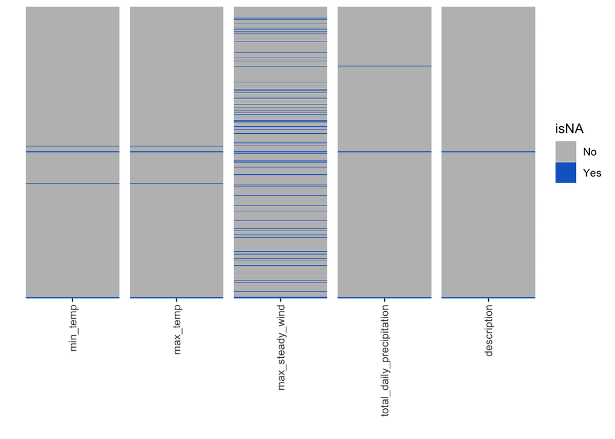

```r
what<-dat[,..vars.considered]
inter.rowname<-as.character(dat[,date])

is.na(what)->to
row.names(to)<-inter.rowname
as.integer(to)->to2
matrix(to2,nrow=nrow(to))->to2
dimnames(to2)<-dimnames(to)

makeheatmap1(to2)
```

## 4.2 Visna() for overall pattern

Visna() is another method to explore the potential patterns of missing-value distribution of continuous days (731 days)

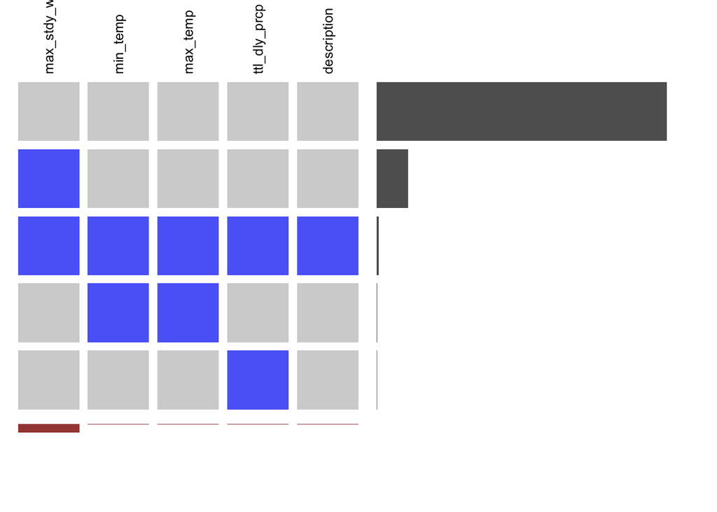

```
##   max_steady_wind min_temp max_temp total_daily_precipitation description
## 1               0        0        0                         0           0
## 3               1        0        0                         0           0
## 5               1        1        1                         1           1
## 4               0        1        1                         0           0
## 2               0        0        0                         1           0
## attr(,"mar")
## attr(,"mar")$rm
##      [,1]
## [1,]  652
## [2,]   71
## [3,]    5
## [4,]    2
## [5,]    1
##
## attr(,"mar")$cm
##           [,1]        [,2]        [,3]        [,4]        [,5]
## [1,] 0.1039672 0.009575923 0.009575923 0.008207934 0.006839945
##
## attr(,"orders")
## attr(,"orders")[[1]]
## [1] 1 3 5 4 2
##
## attr(,"orders")[[2]]
## [1] 3 1 2 4 5
```

```r
library(data.table)
library(ggplot2)
library(grid)
library(extracat)

load('dat.dt.RData')

vars.considered<-c('min_temp','max_temp','max_steady_wind','total_daily_precipitation','description')
what<-dat[,..vars.considered]
visna(what,sort='b',return.data=T,opts=list(mar=c(0.5,0.2)))
```

Merge weather dataset and Bikesharing dataset to one

```r
alldata <- merge(x = dat, y = finaldata, by = "date", all.x = TRUE)
```

# 2.Deciding-Factor Analysis

```r
library(data.table)
library(anytime)
library(ggplot2)
library(RColorBrewer)
library(patchwork)

load('dat.dt.RData')
dat->weather
load('bikedata.dt.RData')
finaldata->bike
colnames(bike)[5] <- "casual"

setDT(weather)
setDT(bike)

bike1 <- bike
bike[,all(registered+casual==total)]
```

```
## [1] TRUE
```

# Variable-Dependency

We want to explore how total rental amount of bike-sharing relates to each variable. Since variables are not the same type, we would split them into quantitative varibles and qualitative varibles and analyze seperately.

2.1 Quantitative-Varible Analysis

- min_temp (daily minimum temperature)
- max_temp (daily maximum temperature)
- max_steady_wind (maximum steady wind of the day)
- total_daily_precipitation (total daily precipitation)

```r
library(pheatmap)

dat2 <- merge(bike,weather,by='date',all.x=T,all.y=T)

mat<-as.matrix(dat2[,.(registered,casual,total)])
row.names(mat)<-dat2[,as.character(date)]

rowSums(is.na(mat))->pan

# Filter missing values out
dat2[pan==0]->dat2
mat[pan==0,]->mat

# Cluster based on variable "registered","casual","total"
hclust(dist(mat))->hh
hh$labels[hh$order]->hh

dat2[match(hh,as.character(date))]->dat3
dat3[,No:=rev(ppoints(NROW(dat3),0.5))]

reshape2::melt(mat) -> dd
names(dd) <- c('date','what','number')
setDT(dd)

dd[,date:=ordered(date,levels=rev(hh))]
dd[,what:=ordered(what,levels=colnames(mat))]
```

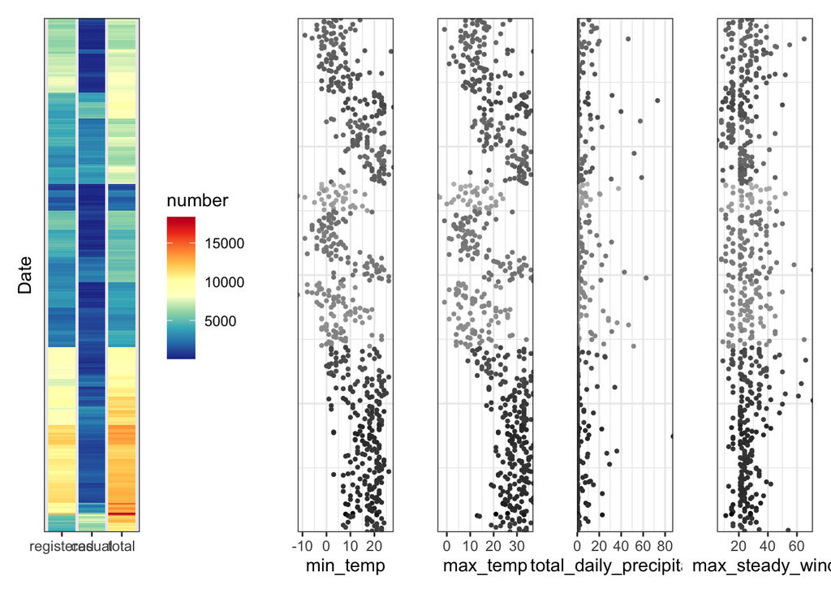

```r
ph<-ggplot(dd,aes(x=what,y=date,fill=number)) +
  geom_tile(width=0.9,colour=NA)+
  theme_bw() %+replace% theme(axis.text.y=element_blank(), axis.ticks.y=element_blank())+
  labs(y='Date',x='')+
  scale_fill_gradientn(colours=c(rev(brewer.pal(5,'YlGnBu')),brewer.pal(5,'YlOrRd')))

# max_temp
pmax<-ggplot(dat3,aes(y=No,x=max_temp,colour=total)) +
  geom_point(size=0.74,show.legend=F) +
  scale_y_continuous(limits=c(0,1),expand=expansion(0))+
  scale_x_continuous(expand=expansion(0))+
  theme_bw() %+replace% theme(axis.text.y=element_blank(), axis.ticks.y=element_blank())+
  labs(y='')+
  scale_color_gradient(low='gray',high='black')

# min_temp
pmin<-ggplot(dat3,aes(y=No,x=min_temp,colour=total)) +
  geom_point(size=0.74,show.legend=F) +
  scale_y_continuous(limits=c(0,1),expand=expansion(0))+
  scale_x_continuous(expand=expansion(0))+
  theme_bw() %+replace% theme(axis.text.y=element_blank(), axis.ticks.y=element_blank())+
  labs(y='')+
  scale_color_gradient(low='gray',high='black')

# total_daily_precipitation
prain<-ggplot(dat3,aes(y=No,x=total_daily_precipitation,colour=total)) +
  geom_point(size=0.74,show.legend=F) +
  scale_y_continuous(limits=c(0,1),expand=expansion(0))+
  scale_x_continuous(expand=expansion(0))+
  theme_bw() %+replace% theme(axis.text.y=element_blank(), axis.ticks.y=element_blank())+
  labs(y='')+
  scale_color_gradient(low='gray',high='black')

# max_steady_wind
pwind<-ggplot(dat3,aes(y=No,x=max_steady_wind,colour=total)) +
  geom_point(size=0.74,show.legend=F) +
  scale_y_continuous(limits=c(0,1),expand=expansion(0))+
  scale_x_continuous(expand=expansion(0))+
  theme_bw() %+replace% theme(axis.text.y=element_blank(), axis.ticks.y=element_blank())+
  labs(y='')+
  scale_color_gradient(low='gray',high='black')

ph+pmin+pmax+prain+pwind+plot_layout(nrow = 1)
```

Heatmap on the left shows such three main clusters/groups of bike-sharing rental amount as High rental amount, Low rental amount and Medium rental amount (from bottom to top). Accordingly, the right four scatterplots present how these three rental groups relate to each quantitative variables. Note that the transparency of data points represents the magnitude of total rental amount: the more total rental amount each point holds, the darker it will be. Based on the plots, it is clearly observed that:

- More bike-sharing activities took place when temperature was above 20 degrees Celsius (68 degrees Fahrenheit) and less people cycled when it was cold, especially when temperature was subzero.
- People prefer to rent and ride bicycles on non-rainy days with precipitation below 10mm. Noticeable, some users did enjoy rainy-cycling with precipitation above 20mm and few users even choose the service when it rained over 70mm.
- Non-windy days with 15-30 km/h wind usually attracted more users to the bike-sharing service. Indeed, some users would choose the service when it blew at over 50 km/h.

2.2 qualitative-Varible Analysis

- Weekday (weekday of the date)
- Season
- Description (weather type of the date)

```r
library(ggridges)

bike1<-melt(bike1,
      id.vars=c('date','season','weekday'),
      variable.name='what',
      value.name='number')

weather[bike1,on=.(date)]->dat1
na.omit(dat1)->dat1

dat1[,year:=year(date)]
dat1[,month:=month(date)]
dat1[,day:=mday(date)]
dat1[,wday:=wday(date)]
```

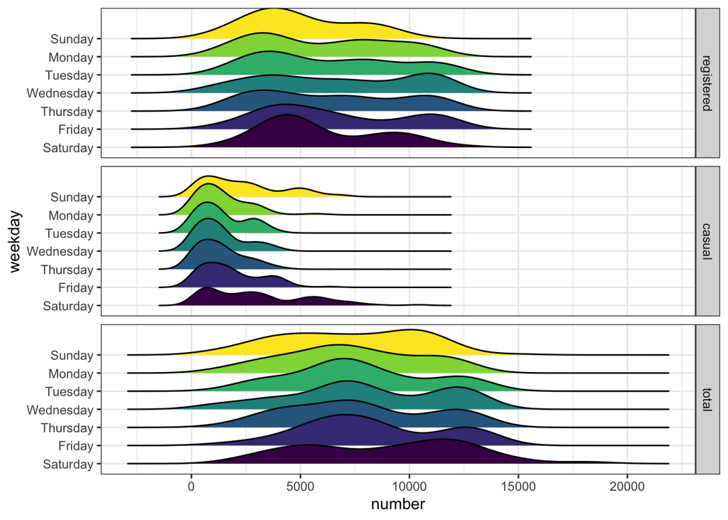

```r
# Weekday
dat1[,weekday:=ordered(weekday,unique(dat1[,.(wday,weekday)])[order(-wday),weekday])]
pweekday <- ggplot(dat1, aes(x = number, y = weekday, fill=weekday))+
  geom_density_ridges(show.legend=F)+
  facet_grid(rows=vars(what))+
  theme_bw()

# Season
dat1[,season:=ordered(season,c('Spring','Summer','Fall','Winter'))]
pseason <- ggplot(dat1, aes(x = number, y = season, fill=season))+
  geom_density_ridges(show.legend=F)+
  facet_grid(rows=vars(what))+
  theme_bw()

# Description
pdesp <- ggplot(dat1, aes(x = number, y = description,fill=description))+
  geom_density_ridges(show.legend=F)+
  facet_grid(rows=vars(what))+
  theme_bw()

pweekday
```

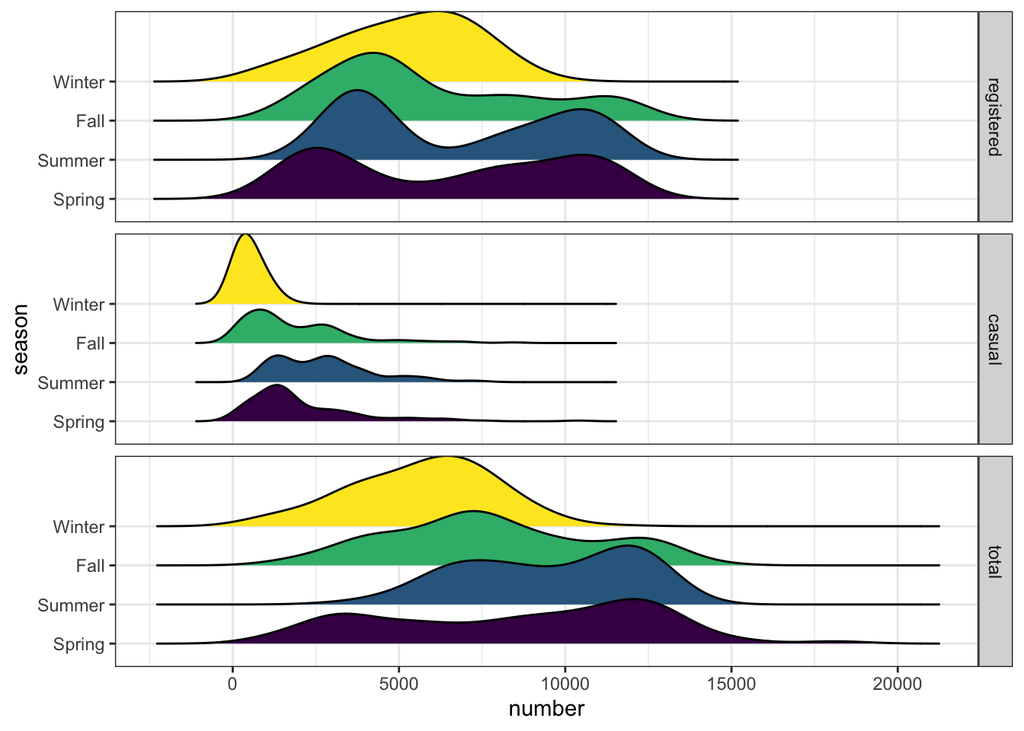

```r
pseason
```

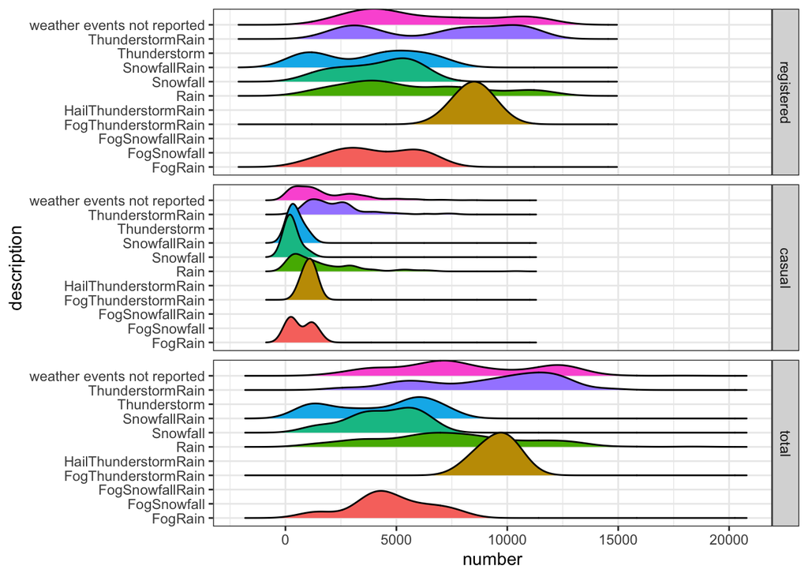

```r
pdesp
```

Based on the ridge-plots, we could observe that:

- Saturday and Sunday tend to attract more users to cycle, whose distributions center on higher total rental amount (over 10,000). Noticeably, Monday through Friday almost have the same distributions, which may imply users’ daily commuting necessity.
- Spring and Summer are users’ favorite seasons to engage in the bike-sharing activiteis while Fall attracted certain amount of users as well. Besides, there was a great variation in Spring’s total rental amount, which implies the distinctive year-on-year decline in 2020, i.e. the Covid-pandemic year.
- As expected, sunny days (Weather events not reported) are users’ top choices to ride bicycles while people cycled less on rainy and snowy days (Rain, Fograin, Snowfall, Snowfallrain). Surprisingly, thunderstrom days (ThunderstormRain and FogThunderstromRain) did not undermine people’s passion for bike-sharing and this phenomenon could be attributed to residents’ adaptation to frequent thunderstroms.